# Building up the case for time-dependant visualizations

## The problem statement

These examples are re-used from section 2.6.5 of https://ggplot2-book.org/getting-started#sec-line.

Let’s first make simple time series plots of the continuous variable `unemploy / pop` over time. Please observe that a time series always has, well, time in the-axis.

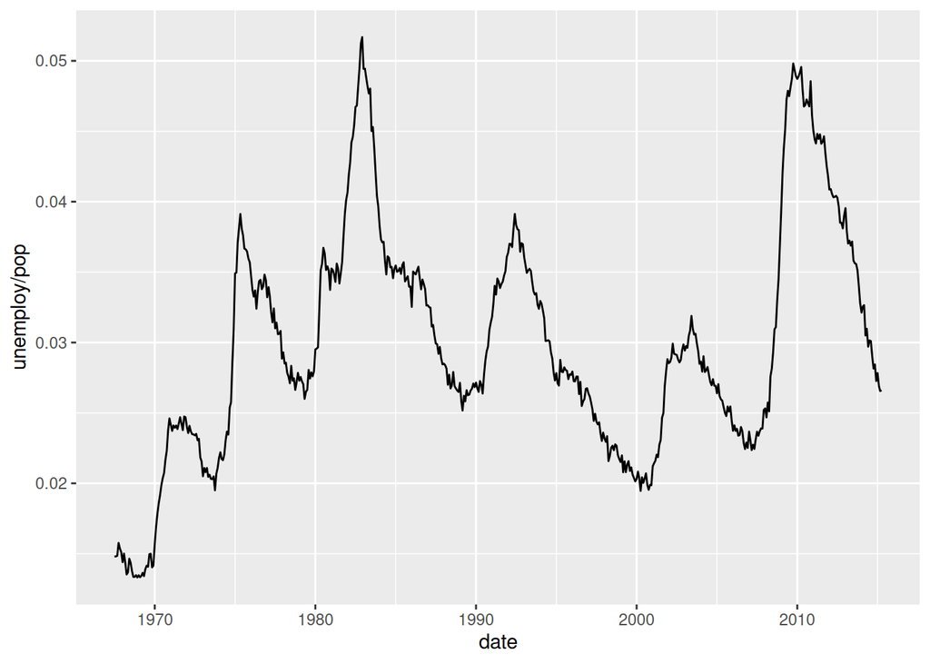

```r
ggplot(economics, aes(date, unemploy / pop)) + geom_line()
```

The variable `unemploy / pop` represents the *“population rate of unemployment as a fraction of the population able to work that is unemployed”*, (https://www.bls.gov/cps/cps_htgm.htm#definitions)

Another variable called `uempmed` from this same dataset tracks the unemployment length measured as the median number of weeks a person lasts unemployed.

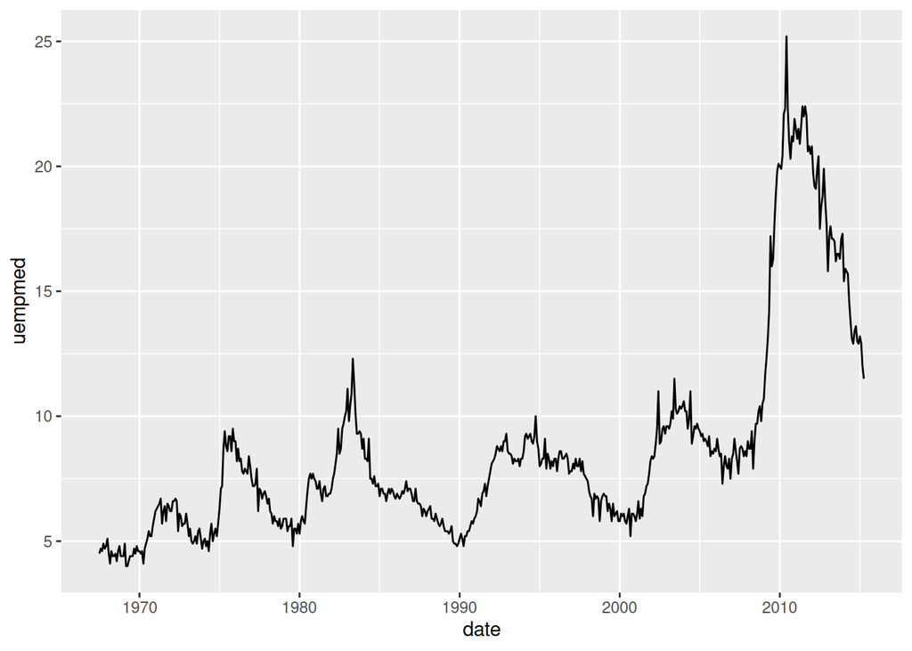

```r
ggplot(economics, aes(date, uempmed)) +
  geom_line()
```

The challenge is to represent both time series in the same scatter plot. In other words how these two variables have evolved over the years. If they are represented on a coordinate plane their intersection represent their values at a point in time.

To represent those points over time using two mappings from the grammar of graphics, one for the points called appropriately `geom_point` and another for their sequential trajectory as they appear in the dataset, ordered by time, called a `geom_path`. The figure below shows such a graph.

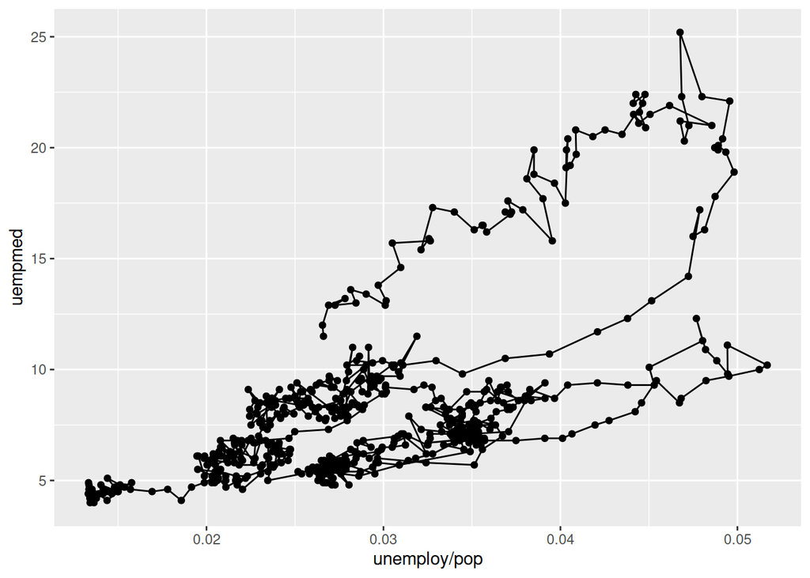

```r
ggplot(economics, aes(unemploy / pop, uempmed)) +
  geom_path() +
  geom_point()
```

The obstacle to understand this plot is in the encoding of time flow with the lines. It is not clear where the points corresponding to the first years the latter ones are, or where all the years in between have happened.

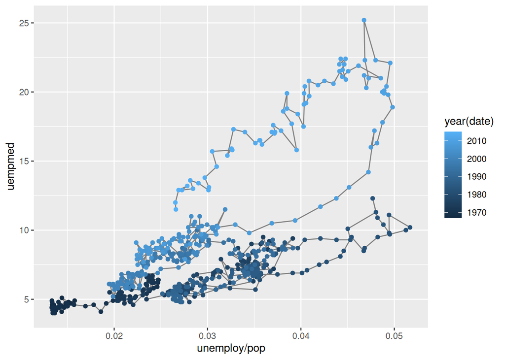

```r
year <- function(x) as.POSIXlt(x)$year + 1900
ggplot(economics, aes(unemploy / pop, uempmed)) +
  geom_path(colour = "grey50") +
  geom_point(aes(colour = year(date)))
```